# Trabalho Final Curso R4DS

Marcelo Chaves de Jesus

## Apresentação

O objetivo do presente trabalho é apresentar a aplicação dos conceitos aprendidos no curso na análise de dados de exportações e importações brasileiras no período de 2012 a 2021.

As técnicas de análise utilizadas consistiram na aplicação de indices de competitividade e de concentração, com foco principalmente nos produtos do agronegócio.

Após a extração dos ìndices buscou-se verificar se existe relação entre a concentração das exportações em determinados produtos ou destinos e as vantagens comparativas e relativas nas exportações.

Por hipótese espera-se que os estados com menores índices de concentração apresentem maiores índices de vantagem comparativa por serem mais diversificados.

## Criação do projeto e preparação do ambiente

O primeiro passo foi criar um novo projeto por meio do camando `usethis::create_project('~/TrabalhoFinalCursoR4DS')`

O camando acima cria o diretório ‘TrabalhoFinalCursoR4DS’ na pasta do usuário, cria a pasta ‘R’, o arquivo ‘.gitignore’ e o arquivo ‘TrabalhoFinalCursoR4DS.Rproj’ e em seguida inicia uma nova sessão do RStudio.

As informações de configuração do Git, bem como a chave SSH foram previamente configuradas de modo que foram necessários apenas os comandos `usethis::use_git()` e `usethis::use_github()` para que o projeto fosse criado e carregado no diretório https://github.com/profmarcelojesus/TrabalhoFinalCursoR4DS.

Seguindo as orientações de organização do projeto foram criadas as pastas ‘data’, ‘data-raw’ e ‘docs’ por meio do camando `usethis::use_directory()`.

## Carregamento dos dados brutos

Os dados utilizados na análise formam obtidos no site do Ministério da Economia no endereço https://balanca.economia.gov.br/. O diretório raiz de onde seriam baixados os arquivos foi salvo na variável `site`.

Para a carga das tabelas dimensão necessárias foi criando um vetor com o nome dos arquivos .csv a serem carregados.

Para evitar a repetição de códigos foi criada uma função que recebe o caminho onde os arquivos estão armazenados e o nome do arquivo. Essas informações são passados por meio dos commandos `tabelas_dimensao <- purrr::map2(nome_tabelas, rep('/tabelas/', 4), carrega_tabelas)`, `exportacoes <- purrr::map2_dfr(c(2012:2021), rep('/comexstat-bd/ncm/EXP_', 10), carrega_tabelas)` e `importacoes <- purrr::map2_dfr(c(2012:2021), rep('/comexstat-bd/ncm/IMP_', 10), carrega_tabelas)`, resultando em três tabelas com os dados brutos a serem analisados.

Os setores de produtos foram definidos de acordo com a classificação do Ministério da Agricultura Pecuária e Abastecimento (MAPA) disponível no endereço https://indicadores.agricultura.gov.br/agrostat/index.htm. Os dados foram copiados manualmente e organizados no arquivo `agrupamentos.csv`

Com a finalidade de obter uma tabela com valores de exportações e importações para cada produto, por ano, pais e setor foram aplicadas as seguintes transformações:

- A coluna VL_FOB que representa o valor da operação de exportação ou importações foi renomeada em cada tabela para V_EXP e V_IMP, respectivamente.
- Os dados foram agrupados por ano, uf e código NCM.
- As tabelas exportacoes e importacoes foram unidas de modo a formar uma única tabela com ambas informações para cada setor/UF/ano nomeada como operacoes.
- Acrescentou-se à tabela operacoes os dados de setor do agronegócio contidos na tabela agrupamento.

A tabela operacoes foi então armazenada na pasta data para servir de base para as próximas etapas.

## Criando as tabelas resumo

As análises realizadas consideraram principalmente o volume de exportações e importações de cada setor do agronegócio para cada UF por ano e também o paíes de destino das exportações. Sendo assim os dados da tabela operacoes foram agrupados nas tabelas operacoes_por_setor e operacoes_por_destino, excluindo-se as informações de UF que não correspondiam aos Estados brasileiros.

Para melhor apresentação dos dados de importações foram organizados com os anos em colunas utilizando a função `tidyr::pivot_wider`.

Foram criadas outras duas tabelas, uma com o principal setor em volume de exportações para cada UF e outra com a UF que se sobressai para cada setor do agronegócio.

## Analizando os dados

Foram calculados para cada UF os dados refentes aos indicadores de vantagem comparativa, que consideram a proporção das exportações de produtos em relação aos demais produtos e em relação às importações e concentração por setor e destino das exportações.

As fórmulas utilizadas para os cálculos são descritas à seguir:

#### Vantagem comparativa revelada

$$\begin{equation}
\label{ivcr}
IVCR_{ij} =
\frac{\left(\frac{X_{ij}}{X_i}\right)}{\left(\frac{X_{wj}}{X_w}\right)}
\end{equation}$$

Onde:

• $X_{ij}$ = valor das exportações locais do produto $j$;

• $X_i$ = total das exportações locais;

• $X_{wj}$ = valor das exportações nacionais do produto $j$;

• $X_w$ = total das exportações nacionais.

Se:

$IVCR < 1$ → não possui vantagem comparativa revelada.

$IVCR > 1$ → possui vantagem comparativa revelada.

$IVCR = 1$ → não possui vantagem e nem desvantagem comparativa (Balassa 1965).

Laursen (1998) apontou uma limitação no índice de vantagem comparativa de Balassa uma vez que os resultados variam entre 0 e 1, e entre 1 e infinito. Como solução sugeriu então um ajuste de modo que o indicador se torne normalizando. Sendo assim o Índice de Vantagem Comparativa Simétrica (VCRS), conforme proposto por Laursen (1998), é dado pela expressão a seguir:

$$\begin{equation}
\label{vcrs}
VCRS_{ij} = \frac{IVCR_{ij}-1}{IVCR_{ij}+1}
\end{equation}$$

#### Vantagem relativa na exportação

Além das medidas de participação de mercado, duas medidas baseadas no histórico comercial geral de uma localidade podem revelar mais sobre sua competitividade: os índices de vantagem relativa na exportação e competitividade revelada. Tais índices podem demonstrar o comportamento das exportações de um produto por um país em comparação com todos os outros produtos e como uma localidade se compara a outra e ao resto do mundo (Vollrath 1989).

$$\begin{equation}
\label{vre}
VRE_{ij} =
ln\left[\frac{\frac{X_{ij}}{X_{ir}}}{\frac{X_{ir}}{X_{wr}}}\right]
\end{equation}$$
$$\begin{equation}
\label{cr}
CR_{ij} =
ln\left[\frac{\frac{X_{ij}}{X_{ir}}}{\frac{X_{ir}}{X_{wr}}}\middle/\frac{\frac{M_{ij}}{M_{ir}}}{\frac{M_{ir}}{M_{wr}}}\right]
\end{equation}$$

onde:

• $X_{jr}$ → total das exportações do produto j excluindo o local $i$;

• $X_{ir}$ → valor das exportações locais excluindo o produto $j$;

• $X_{wr}$ → total das exportações excluindo as exportações do produto $j$; e

• $M$ → valor das importações.

### Índice de comércio intraindústria

De acordo com Bojnec (2001) as medidas de vantagem comparativa, os padrões nos fluxos de comércio e na especialização do comércio são determinados por fatores de oferta e demanda. Nesse sentido, além da participação relativa nas exportações, aspectos como a concentração dos mercados em poucos produtos ou destinos e a existência de fluxos de comércio intra e intersetorial impactam a competitividade das localidades. Grubel and Lloyd (1975) fizeram uma contribuição substancial para o estudo dos determinantes dos fluxos de comércio intraindústria versus interindústria (Greenaway and Milner 1984; Loertscher and Wolter 1980).

A concepção de indústria pode considerar a agregação de produtos que, de acordo com características comuns, são classificados nos mesmos níveis de agregação por organismos internacionais como a União Europeia e a Organização Mundial do Comércio. O comércio intraindústria é definido como o valor das exportações de um setor que corresponde exatamente às importações do mesmo setor. O comércio interindustrial é definido como valor do comércio total remanescente após a subtração das exportações ou importações líquidas da indústria (Grubel and Lloyd 1975, 20).

A análise comparativa do índice de comércio intraindústria de Grubel e Lloyd (GL) entre localidades como Estados ou países se dá pela seguinte expressão:

$$\begin{equation}
\label{gl}
GL_{i} =
\frac{\sum{[(X_{ij}+M_{ij})-|X_{ij}-M_{ij}|}]}{\sum{(X_{ij}+M_{ij})}}
\end{equation}$$

onde $X$ e $M$ representam respectivamente o valor das exportações e importações do setor $j$ e do local $i$, enquanto $(X_{ij} + M_{ij})$ indica o comércio total do setor $j$, $(X_{ij} + M_{ij}) - |X_{ij} - M_{ij}|$ representa o comércio intraindústria e $|X_{ij} - M_{ij}|$ representa o comércio interindústria (Grubel and Lloyd 1975).

### Coeficientes de concentração das exportações

Calculou-se também o índice de Hirschman (1945, 159) para o cálculo de concentração do comércio de determinada localidade por destino e por agregação de produtos que pode ser representado pelas seguintes expressões:

$$\begin{equation}
\label{icp}
ICP_{i} = \sqrt {\sum {\left[\frac{X_{ij}}{X_{i}}\right]^2}}
\end{equation}$$

e,

$$\begin{equation}
\label{icd}
ICD_{i} = \sqrt {\sum {\left[\frac{X_{ik}}{X_{i}}\right]^2}}
\end{equation}$$

onde $X_{ik}$ = valor das exportações do local $i$ para o destino $k$.

Para verificar a relação entre os indices de concentração e os indices de vantagem comparativa adotou-se a Análise de Correção Canônica (ACC), que visa identificar e quantificar a associação entre dois conjuntos de variáveis e “permite que, dentre as variáveis preditoras, sejam identificadas aquelas estatisticamente significantes para explicar o comportamento do conjunto de variáveis dependentes” (Fávero 2017).

A ACC converte as variáveis originais dos dois conjuntos em variáveis canônicas que maximizam a relação linear entre as variáveis consideradas em conjunto. A hipótese do modelo teórico da ACC é dada por:

$$\begin{equation}
\label{acc}
Y_1 + ⋯ + Y_p = f(X_1 + ⋯+ X_q )
\end{equation}$$

onde $Y$ e $X$ representam, respectivamente as variáveis dependentes e explicativas do modelo, sendo $p$ o número de possíveis variáveis dependentes e $q$ o número de possíveis variáveis independentes.

Embora seja preferível que as variáveis apresentem uma relação de dependência, a análise não implica que essa relação seja explícita. Sendo assim, tanto os indices de vantagem comparativa quantos os indices de concentração poderiam ser considerados como variáveis dependentes, uma vez que a classificação de variáveis como dependentes ou independentes é de pouca importância para a estimação estatística das funções canônicas, pois a análise de correlação canônica pondera ambas as variáveis estatísticas para maximizar a correlação e não enfatiza qualquer variável estatística em particular (Hair Jr et al. 2009).

Nesse estudo assumiu-se que os indices de vantagem comparativa podem ser explicados em parte pelo indices de concentração de modo que o percentual total de variância explicada dos índices de competitividade pelos scores do Ranking, chamado de medida de redundância total (MRT), seja significativo. Seguindo Hair Jr et al. (2009), a seleção das variáveis estatísticas para análise considerou três critérios: o nível de significância, a magnitude da correlação canônica e a medida de redundância.

A seguir são apresentados os principais, para cada setor a UF que apresentou o maior volume de exportações no período. Destaca-se o caso de São que aparece como lider em exportações em 10 dos 25 setores analisados.

Principais Estados exportadores por grupo de produtos

| SG_UF_NCM | SETOR | 2012 | 2013 | 2014 | 2015 | 2016 | 2017 | 2018 | 2019 | 2020 | 2021 | TOTAL |
| --- | --- | --- | --- | --- | --- | --- | --- | --- | --- | --- | --- | --- |
| AM | BEBIDAS | 199.65 | 288.78 | 253.40 | 274.85 | 183.44 | 183.04 | 152.32 | 197.35 | 145.10 | 163.91 | 2041.83 |
| BA | CACAU E SEUS PRODUTOS | 242.60 | 181.57 | 207.81 | 268.48 | 289.40 | 260.72 | 199.83 | 197.29 | 200.42 | 224.81 | 2272.93 |
| CE | FRUTAS (INCLUI NOZES E CASTANHAS) | 265.62 | 231.30 | 206.59 | 207.94 | 207.18 | 170.16 | 185.29 | 166.77 | 158.39 | 178.09 | 1977.32 |
| MG | CAFÉ | 3784.76 | 3104.95 | 4114.77 | 3671.93 | 3526.04 | 3454.24 | 3228.50 | 3529.05 | 3825.18 | 4441.42 | 36680.85 |
| MT | CEREAIS, FARINHAS E PREPARAÇÕES | 2455.21 | 3636.19 | 2058.18 | 2511.42 | 2410.38 | 2853.21 | 3020.19 | 4178.91 | 3702.80 | 3110.80 | 29937.30 |
| MT | COMPLEXO SOJA | 8490.18 | 9265.55 | 9852.75 | 8025.78 | 7636.34 | 8957.64 | 10461.03 | 9101.63 | 9796.10 | 13286.93 | 94873.92 |
| MT | FIBRAS E PRODUTOS TÊXTEIS | 1089.54 | 664.60 | 763.92 | 769.11 | 834.89 | 890.28 | 991.64 | 1596.55 | 2117.42 | 2433.38 | 12151.33 |
| MT | PRODUTOS HORTÍCOLAS, LEGUMINOSAS, RAÍZES E TUBÉRCULOS | 19.11 | 18.91 | 35.80 | 53.29 | 18.76 | 62.97 | 59.84 | 71.67 | 105.43 | 122.94 | 568.73 |
| PA | ANIMAIS VIVOS (EXCETO PESCADOS) | 532.54 | 712.80 | 639.81 | 181.17 | 132.05 | 184.87 | 281.52 | 230.05 | 116.46 | 60.60 | 3071.88 |
| PA | CHÁ, MATE E ESPECIARIAS | 133.21 | 161.35 | 206.67 | 227.87 | 173.93 | 154.78 | 95.73 | 74.17 | 65.13 | 100.39 | 1393.22 |
| PA | PESCADOS | 51.49 | 55.69 | 56.87 | 59.48 | 55.84 | 53.88 | 62.96 | 72.55 | 71.52 | 81.57 | 621.85 |
| PR | PRODUTOS FLORESTAIS | 1261.33 | 1361.83 | 1448.21 | 1543.85 | 1833.78 | 2242.13 | 2565.73 | 2328.51 | 2215.70 | 3170.52 | 19971.59 |
| RS | COUROS, PRODUTOS DE COURO E PELETERIA | 668.50 | 791.65 | 881.81 | 740.88 | 703.65 | 631.92 | 592.02 | 563.93 | 453.41 | 643.53 | 6671.31 |
| RS | FUMO E SEUS PRODUTOS | 2243.03 | 2341.00 | 1900.35 | 1606.99 | 1653.84 | 1632.65 | 1554.39 | 1772.30 | 1334.50 | 1216.12 | 17255.18 |
| SC | CARNES | 2968.70 | 2763.35 | 2932.82 | 2341.11 | 2388.93 | 2625.88 | 2939.34 | 3207.42 | 2773.53 | 3369.39 | 28310.48 |
| SP | COMPLEXO SUCROALCOOLEIRO | 9243.93 | 9217.09 | 6757.71 | 5424.14 | 7778.35 | 8283.26 | 5015.20 | 4094.60 | 6502.76 | 6555.17 | 68872.20 |
| SP | DEMAIS PRODUTOS DE ORIGEM ANIMAL | 301.20 | 332.47 | 285.93 | 270.35 | 270.28 | 287.51 | 288.72 | 345.59 | 342.46 | 378.48 | 3103.00 |
| SP | DEMAIS PRODUTOS DE ORIGEM VEGETAL | 546.87 | 453.96 | 481.50 | 508.64 | 601.30 | 730.33 | 801.90 | 677.79 | 637.10 | 708.49 | 6147.87 |
| SP | LÁCTEOS | 96.08 | 93.95 | 122.73 | 59.84 | 50.62 | 59.26 | 32.14 | 29.99 | 31.03 | 29.12 | 604.76 |
| SP | PLANTAS VIVAS E PRODUTOS DE FLORICULTURA | 17.10 | 15.39 | 14.35 | 9.31 | 7.91 | 7.78 | 7.64 | 7.40 | 8.85 | 11.07 | 106.79 |
| SP | PRODUTOS ALIMENTÍCIOS DIVERSOS | 359.02 | 367.65 | 387.66 | 407.41 | 406.00 | 489.55 | 538.69 | 548.90 | 625.80 | 698.80 | 4829.48 |
| SP | PRODUTOS APICOLAS | 16.83 | 17.91 | 33.41 | 22.11 | 28.91 | 42.01 | 29.14 | 16.91 | 19.69 | 25.87 | 252.78 |
| SP | PRODUTOS OLEAGINOSOS (EXCLUI SOJA) | 151.03 | 150.70 | 81.85 | 124.38 | 109.08 | 111.60 | 114.89 | 102.17 | 167.92 | 253.85 | 1367.47 |
| SP | RAÇÕES PARA ANIMAIS | 62.15 | 73.81 | 96.58 | 87.48 | 90.23 | 111.60 | 106.08 | 111.31 | 119.46 | 162.47 | 1021.16 |
| SP | SUCOS | 2090.05 | 2162.83 | 1892.90 | 1793.03 | 1808.57 | 1851.44 | 1988.52 | 1841.73 | 1395.26 | 1589.94 | 18414.27 |

Outra informação importante é o setor predominando em cada UF representando a principal atividade exportadora do Estado. Verifica-se que os produtos do Complexo Soja são os principais produtos de exportação em 11 dos 27 Estados brasileiros, o que indinca alta concentração em poucos produtos.

Principais grupos de produtos exportados por UF

| SG_UF_NCM | SETOR | 2012 | 2013 | 2014 | 2015 | 2016 | 2017 | 2018 | 2019 | 2020 | 2021 | TOTAL |
| --- | --- | --- | --- | --- | --- | --- | --- | --- | --- | --- | --- | --- |
| AM | BEBIDAS | 199.65 | 288.78 | 253.40 | 274.85 | 183.44 | 183.04 | 152.32 | 197.35 | 145.10 | 163.91 | 2041.83 |
| MG | CAFÉ | 3784.76 | 3104.95 | 4114.77 | 3671.93 | 3526.04 | 3454.24 | 3228.50 | 3529.05 | 3825.18 | 4441.42 | 36680.85 |
| DF | CARNES | 147.62 | 143.28 | 169.65 | 149.34 | 95.78 | 97.98 | 83.44 | 27.83 | 49.72 | 103.78 | 1068.44 |
| RO | CARNES | 389.64 | 601.96 | 608.71 | 558.20 | 465.63 | 578.73 | 612.26 | 661.39 | 734.84 | 778.71 | 5990.07 |
| SC | CARNES | 2968.70 | 2763.35 | 2932.82 | 2341.11 | 2388.93 | 2625.88 | 2939.34 | 3207.42 | 2773.53 | 3369.39 | 28310.48 |
| BA | COMPLEXO SOJA | 1429.71 | 1217.42 | 1334.68 | 1365.67 | 808.18 | 1466.83 | 2012.07 | 1472.77 | 1710.76 | 2434.05 | 15252.14 |
| GO | COMPLEXO SOJA | 2285.04 | 2391.17 | 2326.59 | 1813.37 | 1976.81 | 2680.82 | 3502.65 | 2509.80 | 3295.73 | 4291.46 | 27073.44 |
| MA | COMPLEXO SOJA | 783.54 | 705.08 | 757.89 | 705.10 | 381.36 | 718.97 | 984.36 | 817.36 | 810.24 | 1246.74 | 7910.63 |
| MS | COMPLEXO SOJA | 1023.66 | 1404.58 | 1459.50 | 1505.26 | 1177.15 | 1476.48 | 2253.92 | 1317.10 | 2003.54 | 3006.95 | 16628.14 |
| MT | COMPLEXO SOJA | 8490.18 | 9265.55 | 9852.75 | 8025.78 | 7636.34 | 8957.64 | 10461.03 | 9101.63 | 9796.10 | 13286.93 | 94873.92 |
| PA | COMPLEXO SOJA | 182.14 | 241.54 | 328.77 | 321.42 | 325.75 | 434.05 | 567.67 | 530.30 | 761.01 | 813.38 | 4506.03 |
| PI | COMPLEXO SOJA | 145.71 | 89.20 | 174.47 | 292.11 | 97.64 | 314.70 | 638.85 | 443.21 | 433.51 | 670.12 | 3299.52 |
| PR | COMPLEXO SOJA | 5388.06 | 6150.18 | 5484.07 | 4751.95 | 4501.04 | 5659.60 | 6897.24 | 4854.22 | 6054.31 | 6361.58 | 56102.25 |
| RR | COMPLEXO SOJA | 5.04 | 1.90 | 16.02 | 8.98 | 10.27 | 22.38 | 2.22 | 51.93 | 58.89 | 111.95 | 289.59 |
| RS | COMPLEXO SOJA | 3575.80 | 5713.21 | 5374.31 | 5286.98 | 4857.55 | 5479.07 | 6420.22 | 4989.16 | 3815.03 | 7809.04 | 53320.36 |
| TO | COMPLEXO SOJA | 444.27 | 468.65 | 626.80 | 647.63 | 447.80 | 756.23 | 1036.67 | 808.43 | 884.90 | 1323.72 | 7445.10 |
| AL | COMPLEXO SUCROALCOOLEIRO | 1003.48 | 732.04 | 606.68 | 484.23 | 367.98 | 448.50 | 289.33 | 284.65 | 383.35 | 417.41 | 5017.64 |
| PB | COMPLEXO SUCROALCOOLEIRO | 92.60 | 32.52 | 12.15 | 16.02 | 9.57 | 23.25 | 6.31 | 5.48 | 25.80 | 28.58 | 252.27 |
| PE | COMPLEXO SUCROALCOOLEIRO | 340.86 | 233.25 | 201.60 | 179.22 | 133.05 | 147.48 | 83.45 | 89.87 | 183.51 | 208.46 | 1800.75 |
| SP | COMPLEXO SUCROALCOOLEIRO | 9243.93 | 9217.09 | 6757.71 | 5424.14 | 7778.35 | 8283.26 | 5015.20 | 4094.60 | 6502.76 | 6555.17 | 68872.20 |
| CE | FRUTAS (INCLUI NOZES E CASTANHAS) | 265.62 | 231.30 | 206.59 | 207.94 | 207.18 | 170.16 | 185.29 | 166.77 | 158.39 | 178.09 | 1977.32 |
| RN | FRUTAS (INCLUI NOZES E CASTANHAS) | 131.28 | 117.69 | 113.75 | 116.95 | 142.77 | 179.48 | 135.64 | 197.94 | 155.94 | 167.45 | 1458.88 |
| AC | PRODUTOS FLORESTAIS | 5.36 | 3.72 | 2.42 | 2.40 | 3.74 | 7.27 | 12.23 | 14.46 | 13.15 | 16.27 | 81.02 |
| AP | PRODUTOS FLORESTAIS | 20.78 | 47.12 | 62.76 | 59.36 | 50.58 | 55.61 | 59.88 | 54.89 | 59.03 | 61.06 | 531.07 |
| ES | PRODUTOS FLORESTAIS | 1218.05 | 1173.34 | 1056.40 | 1089.35 | 922.75 | 1029.99 | 921.92 | 609.36 | 595.48 | 674.21 | 9290.84 |
| RJ | PRODUTOS FLORESTAIS | 61.76 | 61.21 | 56.12 | 52.47 | 47.18 | 47.08 | 44.12 | 46.35 | 47.73 | 43.08 | 507.09 |
| SE | SUCOS | 95.09 | 45.14 | 47.55 | 68.24 | 73.24 | 38.22 | 43.99 | 25.31 | 23.29 | 32.55 | 492.64 |

A tabela a seguir apresenta o resumo dos indicadores de vantagem comparativa e concentração calculados para servir de base para as análises posteriores.

|  | SG_UF_NCM | CO_ANO | IVCR | VCRS | VRE | CR | ICP | GL | ICD |
| --- | --- | --- | --- | --- | --- | --- | --- | --- | --- |
| 1 | AC | 2012 | 4.95705850517593 | -0.338850366499836 | -0.937780487368924 | -0.242351865740693 | 0.699126070977828 | 0.053798870150414 | 0.324992926467698 |
| 2 | AC | 2013 | 9.05565830266191 | -0.298370396137831 | -0.838664960148558 | -0.941982133084151 | 0.686460325564259 | 0.066197838067407 | 0.478683354353814 |
| 3 | AC | 2014 | 7.14096202970794 | -0.443925269762301 | -1.66641642142926 | -1.02339344499993 | 0.672990350926497 | 0.197908765231312 | 0.453773016016571 |
| 4 | AC | 2015 | 10.1300366923469 | -0.498618931502449 | -2.26390315150456 | -0.250971999897685 | 0.820715104565593 | 0.0676507097572577 | 0.568927133399884 |
| 5 | AC | 2016 | 5.47874357094033 | -0.153403006444117 | -0.274176481547732 | 1.44531559507199 | 0.603496783362375 | 0.0571495038005776 | 0.413421207439608 |
| 6 | AC | 2017 | 4.48777242556854 | -0.247086869287043 | -0.798370553591909 | -0.0552667749224382 | 0.556273222046597 | 0.0329899854110279 | 0.442030618618003 |
| 7 | AC | 2018 | 3.72807043373348 | -0.134852528046784 | 0.391684019930903 | 1.7792625515618 | 0.492102806295645 | 0.00727969092608824 | 0.375253144703398 |
| 8 | AC | 2019 | 1.83675428135157 | -0.266298531672854 | -1.27489996970027 | -1.57797358797114 | 0.562963856467228 | 0.0131050748784159 | 0.358875089839882 |
| 9 | AC | 2020 | 2.31309572060773 | -0.116851004961402 | -0.893994174706512 | -1.46277836250789 | 0.5146487046488 | 0.0230532237602472 | 0.339084950788982 |
| 10 | AC | 2021 | 3.44955708209109 | -0.202933942775996 | -0.373233926960862 | 0.0664171365308577 | 0.505879924623187 | 0.0259130240297945 | 0.354893359671605 |

[output cut: 260 more lines]

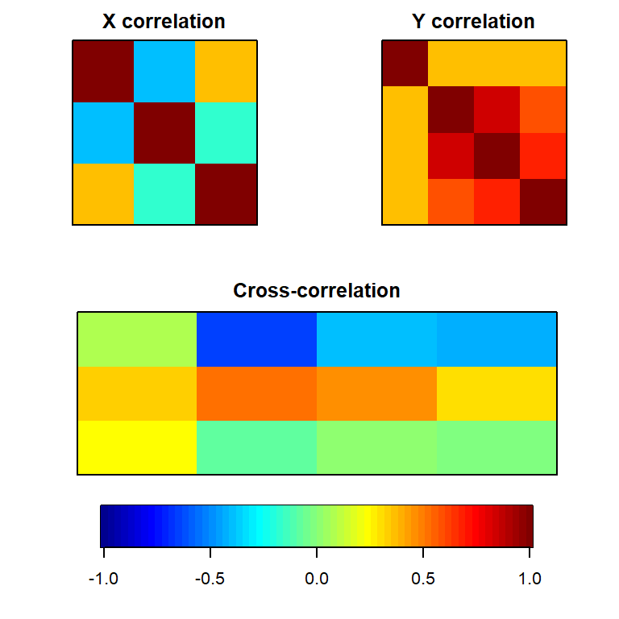

Correlação entre as variáveis

Os scores de correlação entre as variáveis podem ser observados na tabela a seguir.

|  | ICP | GL | ICD | VCRS | VRE | CR |
| --- | --- | --- | --- | --- | --- | --- |
| ICP | 1 | -0.400975886186248 | 0.349551838521388 | -0.632961428542609 | -0.397253757107836 | -0.427079678348616 |
| GL | -0.400975886186248 | 1 | -0.169078100846048 | 0.505650166366705 | 0.453396016882308 | 0.305788405621765 |
| ICD | 0.349551838521388 | -0.169078100846048 | 1 | -0.0776037319514737 | 0.0154129378057577 | -0.000882751649102696 |
| VCRS | -0.632961428542609 | 0.505650166366705 | -0.0776037319514737 | 1 | 0.842848185240036 | 0.588239189858076 |
| VRE | -0.397253757107836 | 0.453396016882308 | 0.0154129378057577 | 0.842848185240036 | 1 | 0.672185637224848 |
| CR | -0.427079678348616 | 0.305788405621765 | -0.000882751649102696 | 0.588239189858076 | 0.672185637224848 | 1 |

As correlações canônicas entre as variáveis indicam que existe forte relação entre o conjunto u1v1. Esse fato confirma que pode existir correlação entre os dois conjuntos de variáveis, ou seja, existe uma relação entre os índices de competividade e de concentração por produto e destino.

Correlações canônicas entre as variáveis estatísticas

| u1v1 | u2v2 | u3v3 |
| --- | --- | --- |
| 0.7433 | 0.2964 | 0.078 |

Traço de Pillai com aproximação F de Rao

|  | stat | approx | df1 | df2 | p.value |
| --- | --- | --- | --- | --- | --- |
| 1 a 3 | 0.6465 | 24.3571 | 9 | 798 | 0* |
| 2 a 3 | 0.0940 | 6.4987 | 4 | 804 | 0 |
| 3 a 3 | 0.0061 | 1.6481 | 1 | 810 | 0.2 |

* Significante ao nível de 95% de confiança

Uma vez determinado o par de variáveis canônicas significativas, a estimação das correlações entre as variáveis originais e as variáveis estatísticas demonstrou que as variáveis VCRS, GL e ICP foram as que melhor se ajustaram à variável canônica v1.

Correlação entre as variáveis padronizadas e as variáveis canônicas independentes

|  | v1 | v2 | v3 |
| --- | --- | --- | --- |
| VCRS | 0.7028 | -0.0934 | -0.0064 |
| VRE | 0.4957 | -0.2140 | 0.0144 |
| CR | 0.4746 | -0.0438 | 0.0589 |
| ICP | -0.9421 | -0.3189 | 0.1035 |
| GL | 0.6234 | -0.6984 | -0.3516 |
| ICD | -0.1493 | -0.3556 | 0.9226 |

Como não era objetivo deste relatório a análise aprofunda dos indicadores, concentrou-se na construção das tabelas com o emprego dos conceitos explorados no curso R4DS. De qualquer forma, foi possível constatar uma ampla gama de possibilidades de análises dos dados utilizados por meio do R.

## Referências

Balassa, Bela. 1965. “Trade Liberalisation and ‘Revealed’ Comparative Advantage.” *The Manchester School* 33 (2): 99–123. https://doi.org/10.1111/J.1467-9957.1965.TB00050.X.

Bojnec, Štefan. 2001. “Trade and Revealed Comparative Advantage Measures: Regional and Central and East European Agricultural Trade.” *Eastern European Economics* 39 (2): 72–98. https://doi.org/10.1080/00128775.2001.11040990.

Fávero, Luiz Paulo. 2017. *Manual de Análise de Dados*. First. Elsevier,.

Greenaway, Sir David, and Chris Milner. 1984. “A Cross Section Analysis of Intra-Industry Trade in the U.K.” *European Economic Review* 25 (3): 319–44.

Grubel, H. G., and P. J. Lloyd. 1975. *Intra-Industry Trade: The Theory and Measurement of International Trade in Differentiated Products*. Macmillan Press.

Hair Jr, Joseph F., William C. Black, Barry J. Babin, Rolph E. Anderson, and Ronald L. Tatham. 2009. *Análise Multivariada de Dados*. Sixth. Bookman.

Hirschman, Albert O. 1945. *National Power and the Structure of Foreign Trade*. Cambridge University Press.

Laursen, Keld. 1998. “Revealed Comparative Advantage and the Alternatives as Measures of International Specialisation.” 98-30. DRUID, Copenhagen Business School, Department of Industrial Economics and Strategy/Aalborg University, Department of Business Studies.

Loertscher, Rudolf, and Frank Wolter. 1980. “Determinants of Intra-Industry Trade: Among Countries and Across Industries.” *Review of World Economics (Weltwirtschaftliches Archiv)* 116 (2): 280–93.

Vollrath, Thomas L. 1989. “Competitiveness and Protection in World Agriculture.” *Agriculture Information Bulletin No. 567*. United States Department of Agriculture. https://doi.org/10.22004/ag.econ.309494.

## Apêndice - Scripts R

```r
## Carregando tabelas

e <- try(is.object(operacoes), silent = TRUE)

if (e != TRUE) {
  operacoes <- readRDS("data/operacoes.RDS")
}

e <- try(is.object(tabelas_dimensao), silent = TRUE)

if (e != TRUE) {
  tabelas_dimensao <- readRDS("data/tabelas_dimensao.RDS")
}


## Criando tabelas agrupadas por ano, uf e setor e por ano, uf e destino

operacoes_por_setor <- operacoes |>
  filter(SG_UF_NCM != "CB" & SG_UF_NCM != "EX" & SG_UF_NCM != "MN" &
                  SG_UF_NCM != "RE" & SG_UF_NCM != "ED" & SG_UF_NCM != "ND" &
                  SG_UF_NCM != "ZN" & !is.na(SETOR)) |>
  group_by(CO_ANO, SG_UF_NCM, SETOR) |>
  summarise(V_EXP = sum(V_EXP, na.rm = TRUE), V_IMP = sum(V_IMP, na.rm = TRUE))
operacoes_por_destino <- operacoes |>
  filter(SG_UF_NCM != "CB" & SG_UF_NCM != "EX" & SG_UF_NCM != "MN" &
                  SG_UF_NCM != "RE" & SG_UF_NCM != "ED" & SG_UF_NCM != "ND" &
                  SG_UF_NCM != "ZN" & !is.na(SETOR)) |>
  group_by(CO_ANO, SG_UF_NCM, CO_PAIS) |>
  summarise(V_EXP = sum(V_EXP, na.rm = TRUE), V_IMP = sum(V_IMP, na.rm = TRUE))
operacoes_por_destino <- left_join(operacoes_por_destino, data.frame(tabelas_dimensao[[3]]))
## Exportações por UF/SETOR/ANO

export_uf_setor_ano <-
  operacoes_por_setor[,-5] |>
  group_by(SETOR, SG_UF_NCM, CO_ANO) |>
  pivot_wider(names_from = CO_ANO, values_from = V_EXP, values_fn = sum, values_fill = 0) |>
  arrange(SG_UF_NCM) |>
  mutate(TOTAL = sum(c_across(where(is.numeric))))

## Importações por UF/SETOR/ANO

import_uf_setor_ano <-
  operacoes_por_setor[,-4] |>
  group_by(SETOR, SG_UF_NCM, CO_ANO) |>
  pivot_wider(names_from = CO_ANO, values_from = V_IMP, values_fn = sum, values_fill = 0) |>
  arrange(SG_UF_NCM)|>
  mutate(TOTAL = sum(c_across(where(is.numeric))))

## Identificando a UF com maior volume de exportações para cada setor

principal_uf_por_setor <-
  export_uf_setor_ano |>
  group_by(SETOR) |>
  filter(TOTAL == max(TOTAL))

## Identificando o setor com maior volume de exportações para cada UF

principal_setor_por_uf <-
  export_uf_setor_ano |>
  group_by(SG_UF_NCM) |>
  filter(TOTAL == max(TOTAL)) |>
  arrange(SETOR)

## Preaparação de indicadores por setor

indicadores_por_setor <-
  operacoes_por_setor |>
  mutate(
    Xij = V_EXP,
    Mij = V_IMP,
    Xi = sum(V_EXP),
    Mi = sum(V_IMP)
  ) |>
  group_by(CO_ANO, SETOR) |>
  mutate(
    Xwj = sum(V_EXP),
    Mwj = sum(V_IMP),
    Xjr = Xi - Xij
  ) |>
  group_by(CO_ANO) |>
  mutate(
    Xw = sum(V_EXP),
    Mw = sum(V_IMP),
    IVCR = (Xij / Xi) / (Xwj / Xw)
  )|>
  mutate(
    Xjr = Xwj - Xij,
    Xir = Xi - Xij,
    Xwr = Xw - Xwj,
    Mjr = Mwj - Mij,
    Mir = Mi - Mij,
    Mwr = Mw - Mwj,
    VCRS = (IVCR - 1) / (IVCR + 1),
    VRE = log((Xij / Xjr) / (Xir / Xwr)),
    CR = log(((Xij / Xjr) / (Xir / Xwr)) / ((Mij / Mjr) / (Mir / Mwr))),
    GLn = ((Xij + Mij) - abs(Xij - Mij)),
    GLd = (Xij + Mij),
    ICP = (Xij / Xi)^2
  )

## Preparação de indicadores por destino

indicadores_por_destino <-
  operacoes_por_destino |>
  mutate(
    Xik = V_EXP,
    Xi = sum(V_EXP)
  ) |>
  mutate(
    ICD = (Xik / Xi)^2
  )

## Resumo de indicadores por UF/ANO

indicadores_por_uf_ano <-
  indicadores_por_setor[,-c(4:14,16:20)] |>
  mutate(
    across(
      .cols = c(IVCR:ICP),
      .fns = ~ ifelse(is.infinite(.), NA, .)
    )
  ) |>
  group_by(SG_UF_NCM, CO_ANO) |>
  summarise(
    across(
      .cols = c(IVCR, VCRS:CR),
      .fns = mean,
      na.rm = T
    ),
    across(
      .cols = c(GLn, GLd, ICP),
      .fns = sum,
      na.rm = T
    )
  ) |>
  mutate(
    GL = GLn / GLd,
    ICP = sqrt(ICP)
  )
indicadores_por_uf_ano |>
  select(-c(7:8))
```

```
## # A tibble: 270 × 8
## # Groups:   SG_UF_NCM [27]
##    SG_UF_NCM CO_ANO  IVCR   VCRS    VRE      CR   ICP      GL
##    <chr>      <dbl> <dbl>  <dbl>  <dbl>   <dbl> <dbl>   <dbl>
##  1 AC          2012  4.96 -0.339 -0.938 -0.242  0.699 0.0538
##  2 AC          2013  9.06 -0.298 -0.839 -0.942  0.686 0.0662
##  3 AC          2014  7.14 -0.444 -1.67  -1.02   0.673 0.198
##  4 AC          2015 10.1  -0.499 -2.26  -0.251  0.821 0.0677
##  5 AC          2016  5.48 -0.153 -0.274  1.45   0.603 0.0571
##  6 AC          2017  4.49 -0.247 -0.798 -0.0553 0.556 0.0330
##  7 AC          2018  3.73 -0.135  0.392  1.78   0.492 0.00728
##  8 AC          2019  1.84 -0.266 -1.27  -1.58   0.563 0.0131
##  9 AC          2020  2.31 -0.117 -0.894 -1.46   0.515 0.0231
## 10 AC          2021  3.45 -0.203 -0.373  0.0664 0.506 0.0259
## # … with 260 more rows
```

```r
indicadores_por_destino_ano <-
  indicadores_por_destino |>
  select(CO_ANO, SG_UF_NCM, ICD) |>
  group_by(SG_UF_NCM, CO_ANO) |>
  summarise(ICD = sum(ICD, na.rm =T)) |>
  mutate(ICD = sqrt(ICD))
indicadores_por_uf_ano <- full_join(indicadores_por_uf_ano, indicadores_por_destino_ano)
```

```r
## Teste normalidade multivariada

indicadores_por_uf_ano <- indicadores_por_uf_ano[,-c(7:8)]

indicadores_por_uf_ano$SG_UF_NCM <- as_factor(indicadores_por_uf_ano$SG_UF_NCM)

res <- mvn(data = indicadores_por_uf_ano[,-c(2:3)], subset = 'SG_UF_NCM', mvnTest = 'hz', tol = 1e-35)

res.multivariateNormality <- map_dfr(res$multivariateNormality, ~ bind_rows(.))

res.multivariateNormality$UF <- names(res$multivariateNormality)

## Violação da normalidade multivariada por UF

res.multivariateNormality <-
  res.multivariateNormality |>
  relocate(UF) |>
  filter(MVN == 'NO')

## Teste normalidade univariada

unir_resultados <- function(tabela, uf){
   tabela |> mutate(UF = uf)
}

res.univariateNormality <- map2_dfr(res$univariateNormality, names(res$univariateNormality), unir_resultados)

## Violação da normalidade univariada por variável/UF

res.univariateNormality <-
  res.univariateNormality |>
  relocate(UF) |>
  mutate(Normality = trimws(Normality)) |>
  filter(Normality == 'NO')

table(res.univariateNormality$Variable)
```

```
##
##    CR        GL        ICD       ICP       VRE      VCRS
##         1         4         1         5         1         1
```

```r
## Verificando outliers multivariados

indicadores_por_uf_ano[,-2] |>
  group_by(SG_UF_NCM) |>
  doo(~mahalanobis_distance(.)) |>
  filter(is.outlier == TRUE)
```

```
## # A tibble: 0 × 10
## # … with 10 variables: SG_UF_NCM <fct>, IVCR <dbl>, VCRS <dbl>, VRE <dbl>,
## #   CR <dbl>, ICP <dbl>, GL <dbl>, ICD <dbl>, mahal.dist <dbl>,
## #   is.outlier <lgl>
```

```r
## Verificando homogeneidade das matrizes de covariância e variâncias

res <- box_m(indicadores_por_uf_ano[,-c(1:2)], indicadores_por_uf_ano$SG_UF_NCM)

## Verificando a homogeneidade de variâncias

teste_levene <- function(coluna) {
  leveneTest(coluna ~ as_factor(SG_UF_NCM),
             indicadores_por_uf_ano,
             center = mean)
}

res <- map_dfr(indicadores_por_uf_ano[,-c(1:2)], teste_levene)

res <- res |> filter(!is.na(res$`Pr(>F)`))

res$Variavel <- names(indicadores_por_uf_ano[,-c(1:2)])

res <- res |> relocate(Variavel)

## Verificando a presença de multicolinearidade

cor(indicadores_por_uf_ano[,-c(1:3)])
```

```
##             VCRS         VRE            CR        ICP         GL           ICD
## VCRS  1.00000000  0.84284819  0.5882391899 -0.6329614  0.5056502 -0.0776037320
## VRE   0.84284819  1.00000000  0.6721856372 -0.3972538  0.4533960  0.0154129378
## CR    0.58823919  0.67218564  1.0000000000 -0.4270797  0.3057884 -0.0008827516
## ICP  -0.63296143 -0.39725376 -0.4270796783  1.0000000 -0.4009759  0.3495518385
## GL    0.50565017  0.45339602  0.3057884056 -0.4009759  1.0000000 -0.1690781008
## ICD  -0.07760373  0.01541294 -0.0008827516  0.3495518 -0.1690781  1.0000000000
```

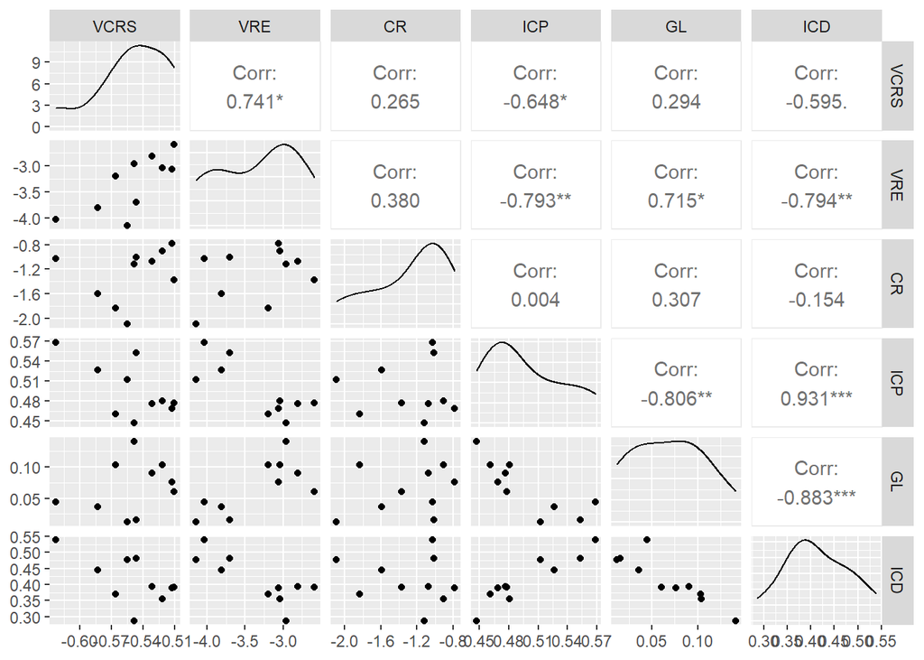

```r
## Verificando a relação linear entre as variáveis dependentes

plots <- indicadores_por_uf_ano[,-c(2:3)] |>
  group_by(SG_UF_NCM) |>
  doo(~ggpairs(.), result = 'plots')

ms <- plots |> filter(SG_UF_NCM  == 'MS')

ms$plots
```

```r
## Modelo MANOVA

variaveis <- cbind(indicadores_por_uf_ano$VCRS,
                   indicadores_por_uf_ano$VRE,
                   indicadores_por_uf_ano$CR,
                   indicadores_por_uf_ano$ICP,
                   indicadores_por_uf_ano$GL,
                   indicadores_por_uf_ano$ICD)

modelo <- manova(variaveis   ~ SG_UF_NCM, data = indicadores_por_uf_ano)

summary(modelo, test = "Pillai")
```

```
##            Df Pillai approx F num Df den Df    Pr(>F)
## SG_UF_NCM  26 3.9819    18.44    156   1458 < 2.2e-16 ***
## Residuals 243
## ---
## Signif. codes:  0 '***' 0.001 '**' 0.01 '*' 0.05 '.' 0.1 ' ' 1
```

```r
## Teste ANOVA

summary.aov(modelo)
```

```
##  Response 1 :
##              Df  Sum Sq Mean Sq F value    Pr(>F)
## SG_UF_NCM    26 10.2720 0.39508  62.641 < 2.2e-16 ***
## Residuals   243  1.5326 0.00631
## ---
## Signif. codes:  0 '***' 0.001 '**' 0.01 '*' 0.05 '.' 0.1 ' ' 1
##
##  Response 2 :
##              Df Sum Sq Mean Sq F value    Pr(>F)
## SG_UF_NCM    26 349.07 13.4258   24.76 < 2.2e-16 ***
## Residuals   243 131.77  0.5422
## ---
## Signif. codes:  0 '***' 0.001 '**' 0.01 '*' 0.05 '.' 0.1 ' ' 1
##
##  Response 3 :
##              Df Sum Sq Mean Sq F value    Pr(>F)
## SG_UF_NCM    26 388.09 14.9265  16.992 < 2.2e-16 ***
## Residuals   243 213.46  0.8784
## ---
## Signif. codes:  0 '***' 0.001 '**' 0.01 '*' 0.05 '.' 0.1 ' ' 1
##
##  Response 4 :
##              Df Sum Sq  Mean Sq F value    Pr(>F)
## SG_UF_NCM    26 4.2571 0.163736  35.021 < 2.2e-16 ***
## Residuals   243 1.1361 0.004675
## ---
## Signif. codes:  0 '***' 0.001 '**' 0.01 '*' 0.05 '.' 0.1 ' ' 1
##
##  Response 5 :
##              Df  Sum Sq  Mean Sq F value    Pr(>F)
## SG_UF_NCM    26 1.48234 0.057013  51.253 < 2.2e-16 ***
## Residuals   243 0.27031 0.001112
## ---
## Signif. codes:  0 '***' 0.001 '**' 0.01 '*' 0.05 '.' 0.1 ' ' 1
##
##  Response 6 :
##              Df Sum Sq  Mean Sq F value    Pr(>F)
## SG_UF_NCM    26 2.6798 0.103068  21.047 < 2.2e-16 ***
## Residuals   243 1.1900 0.004897
## ---
## Signif. codes:  0 '***' 0.001 '**' 0.01 '*' 0.05 '.' 0.1 ' ' 1
```

```r
## Testes post-hocs

indicadores_por_uf_ano$SG_UF_NCM <- as_factor(indicadores_por_uf_ano$SG_UF_NCM)

res <- TukeyHSD(x = aov(VCRS ~ SG_UF_NCM, data = indicadores_por_uf_ano), 'SG_UF_NCM', conf.level = 0.95)

res <- data.frame(res$SG_UF_NCM)

res[res$p.adj > 0.05, ]
```

```
##                diff          lwr          upr      p.adj
## AP-AC -0.0911961198 -0.224058499 0.0416662595 0.68021773
## CE-AC  0.0681751562 -0.064687223 0.2010375355 0.97736209
## MG-AC -0.0853665446 -0.218228924 0.0474958347 0.79535658
## PA-AC -0.0120701364 -0.144932516 0.1207922429 1.00000000
## PB-AC -0.1030633627 -0.235925742 0.0297990166 0.41918894
## PI-AC  0.0429629046 -0.089899475 0.1758252839 0.99998631
## PR-AC -0.0888293979 -0.221691777 0.0440329814 0.72936576
## RJ-AC  0.1130811528 -0.019781226 0.2459435321 0.23482969
## RN-AC -0.0310601120 -0.163922491 0.1018022673 0.99999998
## RR-AC -0.0894129582 -0.222275337 0.0434494211 0.71750807
## RS-AC  0.0333037235 -0.099558656 0.1661661028 0.99999993
## SC-AC -0.0934017897 -0.226264169 0.0394605897 0.63235962
## DF-AL  0.1179534613 -0.014908918 0.2508158406 0.16809345
## RO-AL  0.0962944177 -0.036567962 0.2291567970 0.56793893
## TO-AL  0.1284245299 -0.004437849 0.2612869093 0.07376298
## BA-AM  0.0851561366 -0.047706243 0.2180185159 0.79909428
## ES-AM -0.0097043448 -0.142566724 0.1231580345 1.00000000
## GO-AM  0.0015137072 -0.131348672 0.1343760865 1.00000000
## MA-AM -0.0841136676 -0.216976047 0.0487487117 0.81710324
## MS-AM -0.0304119444 -0.163274324 0.1024504349 0.99999999
## MT-AM -0.0656132658 -0.198475645 0.0672491135 0.98595473
## PE-AM  0.0183971497 -0.114465230 0.1512595290 1.00000000
## SE-AM  0.0654598936 -0.067402486 0.1983222729 0.98637098
## BA-AP -0.0730855496 -0.205947929 0.0597768297 0.94999790
## MG-AP  0.0058295751 -0.127032804 0.1386919544 1.00000000
## PA-AP  0.0791259833 -0.053736396 0.2119883626 0.89052812
## PB-AP -0.0118672430 -0.144729622 0.1209951363 1.00000000
## PR-AP  0.0023667218 -0.130495657 0.1352291011 1.00000000
## RN-AP  0.0601360077 -0.072726372 0.1929983870 0.99572569
## RR-AP  0.0017831616 -0.131079218 0.1346455409 1.00000000
## RS-AP  0.1244998433 -0.008362536 0.2573622226 0.10206174
## SC-AP -0.0022056699 -0.135068049 0.1306567094 1.00000000
## SE-AP -0.0927817926 -0.225644172 0.0400805867 0.64596559
## ES-BA -0.0948604814 -0.227722861 0.0380018979 0.60001315
## GO-BA -0.0836424295 -0.216504809 0.0492199498 0.82495748
## MG-BA  0.0789151247 -0.053947255 0.2117775040 0.89314497
## MS-BA -0.1155680810 -0.248430460 0.0172942983 0.19880031
## PB-BA  0.0612183066 -0.071644073 0.1940806859 0.99448542
## PE-BA -0.0667589870 -0.199621366 0.0661033923 0.98251135
```

[output cut: 61 more lines]

```
## RN-PR  0.0577692859 -0.075093093 0.1906316652 0.99764004
## RR-PR -0.0005835602 -0.133445940 0.1322788191 1.00000000
## RS-PR  0.1221331215 -0.010729258 0.2549955008 0.12301318
## SC-PR -0.0045723917 -0.137434771 0.1282899876 1.00000000
## SE-PR -0.0951485144 -0.228010894 0.0377138649 0.59358529
## RS-RJ -0.0797774293 -0.212639809 0.0530849500 0.88218962
## RR-RN -0.0583528461 -0.191215225 0.0745095332 0.99725453
## RS-RN  0.0643638356 -0.068498544 0.1972262149 0.98906421
## SC-RN -0.0623416776 -0.195204057 0.0705207017 0.99289210
## TO-RO  0.0321301123 -0.100732267 0.1649924916 0.99999997
## RS-RR  0.1227166817 -0.010145698 0.2555790610 0.11755496
## SC-RR -0.0039888315 -0.136851211 0.1288735478 1.00000000
## SE-RR -0.0945649542 -0.227427334 0.0382974251 0.60659680
## SC-RS -0.1267055132 -0.259567892 0.0061568661 0.08523032
## SE-SC -0.0905761227 -0.223438502 0.0422862566 0.69334970
```

```r
## Medindo o tamanho do efeito da variável independente

effectsize::eta_squared(modelo)
```

```
## # Effect Size for ANOVA (Type I)
##
## Parameter | Eta2 (partial) |       95% CI
## -----------------------------------------
## SG_UF_NCM |           0.66 | [0.57, 1.00]
##
## - One-sided CIs: upper bound fixed at [1.00].
```

```r
#### Carregando conjuntos de variáveis X e Y
# x - variáveis independentes (Indicadores de Concentração)
# y - variáveis dependentes (Vantagens Comparativas)

X <- as.matrix(indicadores_por_uf_ano[,7:9])
Y <- as.matrix(indicadores_por_uf_ano[,4:6])

#### Analisando a matriz de correlação entre X e Y quanto à correlação dentro e entre os grupos.

#### Calculando a matriz e salvando em "correl"

#### Correl, cache=TRUE}
correl <- matcor(X, Y)

#### Obtermos a correlação canonica

# X - matriz numérica (n * p), contendo as coodenadas X
# Y - matriz numérica (n * q), contendo as coodenadas Y

#### ccyx, cache=TRUE}

ccyx <- cc(X,Y)

#### Obtendo a correlação canônica e salvando no objeto v.ca
#### ca, cache=TRUE}

v.ca <- ccyx$cor

#### Testes multivariados de significância para ambas funções canônicas

#### rho, cache=TRUE}
rho <- ccyx$cor

#### Definindo o número de observações "n", o número de variáveis no primeiro
# conjunto de dados "p" e o número de variáveis no segundo conjunto "q".
#### npq, cache=TRUE}

n <- dim(indicadores_por_uf_ano[,c(4:9)])[1]
p <- dim(X)[2]
q <- dim(Y)[2]

#### Lambda de Wilks
#### Wilks, cache=TRUE}
p.asym(rho, n, p, q, tstat = "Wilks")
```

```
## Wilks' Lambda, using F-approximation (Rao's F):
##               stat    approx df1      df2      p.value
## 1 to 3:  0.4056438 32.047461   9 642.6572 0.000000e+00
## 2 to 3:  0.9065777  6.659664   4 530.0000 3.106782e-05
## 3 to 3:  0.9939082  1.630339   1 266.0000 2.027696e-01
```

```r
#### Traço de Pillai
#### Pillai, cache=TRUE}
p.asym(rho, n, p, q, tstat = "Pillai")
```

```
##  Pillai-Bartlett Trace, using F-approximation:
##                 stat    approx df1 df2      p.value
## 1 to 3:  0.646512429 24.357087   9 798 0.000000e+00
## 2 to 3:  0.093957602  6.498693   4 804 3.783273e-05
## 3 to 3:  0.006091759  1.648121   1 810 1.995819e-01
```

```r
#### Traço de Hoteling
#### Hoteling, cache=TRUE}
p.asym(rho, n, p, q, tstat = "Hotelling")
```

```
##  Hotelling-Lawley Trace, using F-approximation:
##                 stat    approx df1 df2      p.value
## 1 to 3:  1.337369743 39.031384   9 788 0.000000e+00
## 2 to 3:  0.102459051  6.779374   4 794 2.287652e-05
## 3 to 3:  0.006129096  1.634425   1 800 2.014628e-01
```

```r
#### Traço de gcr de Roy
#### Roy, cache=TRUE}
p.asym(rho, n, p, q, tstat = "Roy")
```

```
##  Roy's Largest Root, using F-approximation:
##               stat   approx df1 df2 p.value
## 1 to 1:  0.5525548 109.4954   3 266       0
##
##  F statistic for Roy's Greatest Root is an upper bound.
```

```r
#### Proporção da variância total explicada
#### Comput loadings, cache=TRUE}
loadings <- comput(X,Y,ccyx)

#### PVTE Uk: Variância das variáveis independentes explicada pelas variáveis canônicas
#### pvte_u}
pvte.u <-(colSums((loadings$corr.X.xscores)^2))/(dim(X)[2])*100

#### PVTE Vk: Variância das variáveis dependentes explicada pelas variáveis canônicas
#### pvte_v}
pvte.v <-(colSums((loadings$corr.Y.yscores)^2))/(dim(Y)[2])*100

#### Índice de redundância (IR)

# Sintetiza a PVTE e o R² canônico em um único indicador
# R² canônico: indica o quanto da variancia da variável canônica
# dependente é explicada pela variável canônica independente.
# É o quadrado da correlação canônica.
#### IR}
r2.c <-ccyx$cor^2

#### Calculando IR para as variáveis canônicas Uk
#### IRx}
ir.x <-(colSums((loadings$corr.X.xscores)^2))/(dim(X)[2])*(ccyx$cor^2)*100

#### Calculando IR para as variáveis canônicas Vk
#### IRy}
ir.y <-(colSums((loadings$corr.Y.yscores)^2))/(dim(Y)[2])*(ccyx$cor^2)*100

#### Coeficientes padronizados (pesos canônicos)

# A magnitude dos pesos canônicos (coeficientes padronizados) representa
# a contribuição relativa de cada variável para com a respectiva variável
# estatística latente (variável canônica).

#### Variáveis dependentes;
#### sy}
sy <- diag(sqrt(diag(cov(Y))))

#### Variáveis independentes;
#### sx}
sx <- diag(sqrt(diag(cov(X))))

tabela8 <- data.frame("u1v1" = v.ca[1], "u2v2" = v.ca[2], "u3v3" = v.ca[3])

tabela9 <- p.asym(rho, n, p, q, tstat = "Pillai")
```

```
##  Pillai-Bartlett Trace, using F-approximation:
##                 stat    approx df1 df2      p.value
## 1 to 3:  0.646512429 24.357087   9 798 0.000000e+00
## 2 to 3:  0.093957602  6.498693   4 804 3.783273e-05
## 3 to 3:  0.006091759  1.648121   1 810 1.995819e-01
```

```r
tabela9 <- data.frame(tabela9$stat, tabela9$approx, tabela9$df1, tabela9$df2, tabela9$p.value)

colnames(tabela9) <- c("stat", "approx", "df1", "df2", "p.value")

row.names(tabela9) <- c("1 a 3", "2 a 3", "3 a 3")

tabela9[,5] <- cell_spec(round(tabela9[,5], 3))

tabela9[1,5]  <- paste0(tabela9[1,5], footnote_marker_symbol(1))

tabela10 <- rbind(loadings$corr.Y.xscores, loadings$corr.X.xscores)
colnames(tabela10) <- c("v1", "v2", "v3")
row.names(tabela10) <- str_replace(row.names(tabela10), "z", "")
```